# Lecture 7: Point Level Models - Simulation and Model Fitting

# Class Intro

## Intro Questions

- What are some basic guidelines for EDA for point referenced data?
- For Today:
  - Data Simulation
  - Classical Model Fitting

# Model Simulation

## Simulating Spatial Process

- Soon we will look at fitting models for spatial point data
- Simulating data gives a deeper understanding of the model fitting process
- Simulate a mean-zero, isotropic spatial process with a spherical covariance function

## Simulating Spatial Process

1. Construct spatial locations
2. Calculate distances
3. Define covariance function and set parameters
4. Sample realization of the process
5. Visualize realization of spatial process

## 1. Construct Spatial Locations

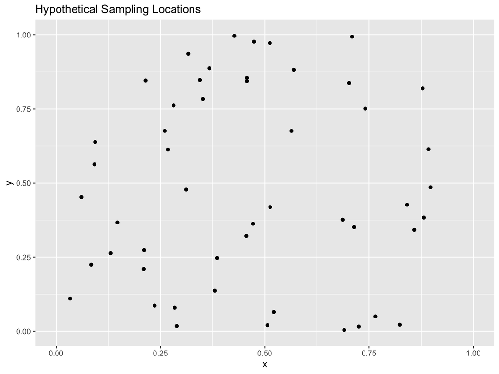

## 2. Calculate Distances

```r
dist.mat <- dist(coords, diag = T, upper = T) %>% as.matrix()
```

## 3. Define Covariance Function and Set Parameters

- Use spherical covariance with no nugget:
  $$C(d) = \begin{cases}
  0 \text{ if } d \geq \frac{1}{\phi} \\
  \sigma^2 \left[1 - \frac{3}{2}\phi d + \frac{1}{2} (\phi d)^3 \right] \; \; \text{ if } 0 \leq d \leq \frac{1}{\phi}
  \end{cases}$$

## 4. Sample realization of the process

- This requires a distributional assumption, we will use the Gaussian distribution
- What about the rest of the locations on the map?

## 5. Vizualize Spatial Process

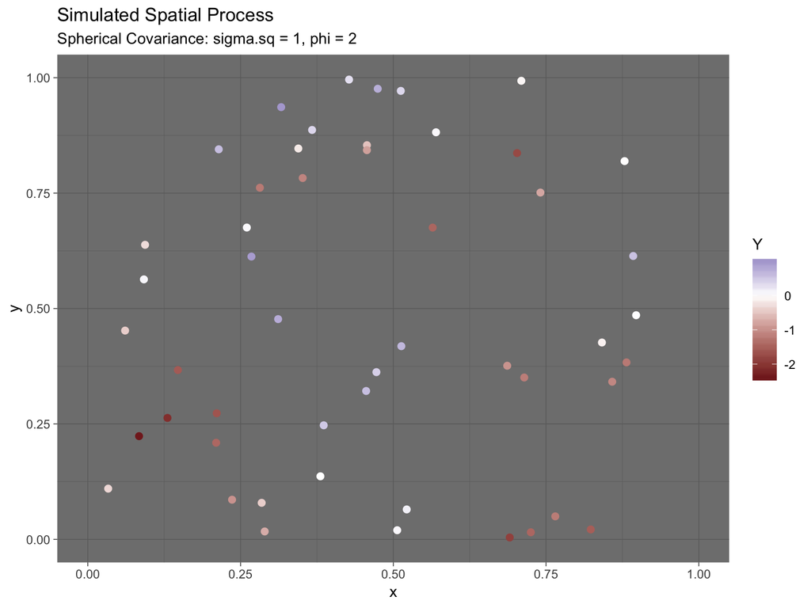

## Extra: Gridded Spatial Process

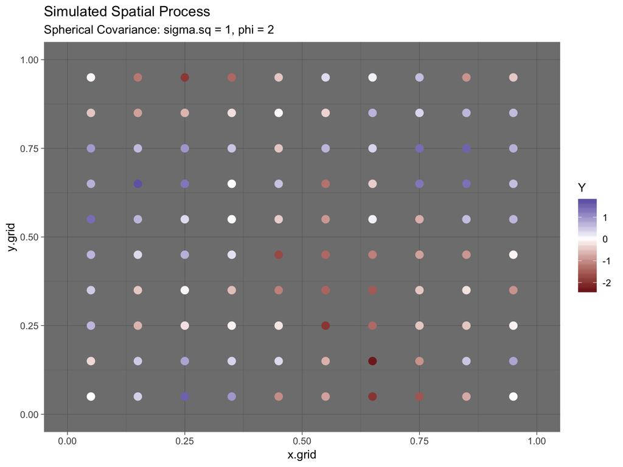

## Extra: Gridded Spatial Process

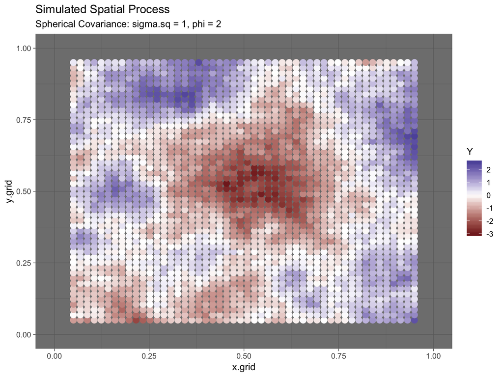

## Simulated Spatial Process: Exercise

How does the spatial process change with:

- another draw with same parameters?
- a different value of $\phi$
- a different value of $\sigma^2$
- adding a nugget term, $\tau^2$

# Model Fitting

## Classical Model Fitting

- The classical approach to spatial prediction is rooted in the minimum the mean-squared error.
- This approach is often referred to as *Kriging* in honor of D.G. Krige a South African mining engineer.
- As a result of Krige’s work (along with others), point-level spatial analysis and geostatistical analysis are used interchangeably.

## Model Fitting Framework

## Additional Resources

- [Meuse Data Tutorial](https://cran.r-project.org/web/packages/gstat/vignettes/gstat.pdf)
- [Textbook Data Sets](https://www.counterpointstat.com/hierarchical-modeling-and-analysis-for-spatial-data.html/)